# Project Report

Group 8

# **1. Introduction**

To begin with, the meaning and the duty of the EPIAS should be clarified. EPIAS is the only institution that regulates the electricity market, and it prevents itself from manipulative and unethical behaviors of self-seeker entities and destabilization of the electricity prices. To organize and prevent unethical behaviors, EPIAS sets some rules to regulate and also provides the real-time electricity consumption amounts in hourly basis for each city with transparency, which prevents the entities from being disinformed and helps the electricity producers to forecast the other day’s electricity consumption, i.e. let electricity demanding entities whether distributor or producer to be kept updated on the latest electricity consumptions, with less error.

Forecasting for the demand data for tomorrow based on the real-time consumption amounts of past has become of more importance for either distributors or producers nowadays due to increasing competitiveness of the electricity market. To maximize the profits that will be gained for the tomorrow’s electricity consumption, the distributor or the producer should declare the maximum amount of price that can be paid in return for a unit of electricity for tomorrow should be declared. Yet, if the prices are not grounded on statistical and analytical basis, it can be frankly declared that the oncoming profits will not be gained. Additionally, not only the consumption amounts of the market but also the condition of the market in near future together with the other agents’ future decisions concerning the market. Therefore, forecasting procedure should be picked over attentively and extensively.

The aim of the study is to forecast the next-day’s hourly consumption values for Turkish electricity market by using the former electricity consumption amounts of Turkey starting from 2017-01-01 together with the temperatures of seven cities. In other words, predictions should be made about the 24 hours’ consumption one-by-one for tomorrow. Former consumption data is taken from an Excel document. The daily data is updated by lecturer and also the updated data is taken from API and used with formerly taken data in R.

Before creation of the model, we need to describe and visualize the data to mention about its properties so as to decide which things should be taken into consideration before modeling. Let’s examine the data:

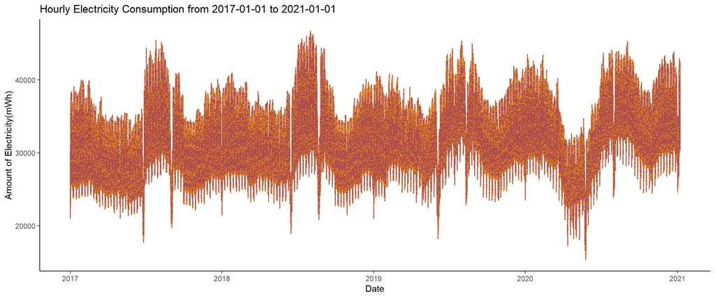

```r
ggplot(rawconsumption, aes(x=rawconsumption$event_date, y=rawconsumption$consumption)) +
  geom_line(size = 0.6, color="darkred", alpha = 0.7) +
  geom_point(size = 0.2, color="orange", alpha = 0.5) +
  labs(title = "Hourly Electricity Consumption from 2017-01-01 to 2021-01-01",
       x = "Date",y = "Amount of Electricity(mWh)") +
  theme(axis.text.x = element_text(angle = 60, hjust = 1)) +
  theme_classic()
```

When the hourly consumption data is considered, the wave-like shape can be detected easily, which means that seasonality exist clearly at the data. Likewise, the seasonality’s existence can be checked also by the period of increases and decreases are similar for each year. Moreover, it can be found out that without difficulty that the consumption of the electricity has 24-hour basis as minimum repetitive units and seasons and years as maximum repetitive units, indicating the seasonality again.

More, Islamic religion includes two religious feasts, which are Ramadan and Sacrifice, i.e. Eid Qurban, provoking 2 great decreases in consumption for each year with same gaps, 11 days. To clarify, these religious feasts induce the electricity to be consumed less than expected having same gaps between these 2 great decreases, as it can be seen.

When it comes to stationarity condition, it can easily be said that the consumption data is not stationary due to having obvious seasonality effect. Moreover, variance of the consumption at the last year is higher than former years. Therefore, it can easily be argued that stationarity condition is not satisfied due to seasonality at first sight along with a great change of the variance between 2020 and 2021.

# **2. Related Literature**

There are many studies in the literature on electricity energy consumption estimation. In these studies, it is possible to find neural networks, econometric models, genetic algorithm, regression models, grey models, ARIMA models for different places/countries. Egelioglu and his study partners used multiple regression models to examine the relationship between energy consumption with the price of electricity, the number of customers and the number of tourists is determined in Northern Cyprus. Tso and Yau examined and compared the accuracy of regression models, decision trees, and neural networks in forecasting electricity energy consumption for Hong Kong. Al-Ghandoor and his partners developed an empirical multivariate regression model to forecast the electricity requirement of Jordan’s industry. Furthermore, ARIMA and GM models were used to forecast primary energy consumption of PCR in Yuan’s research. Lee and Tong predicted consumption of energy by using a genetic programming model which uses a genetic algorithm. We can diversify these studies.

On the other hand, some researchers also studied estimation of Turkey’s energy consumption. Yumurtaci and Asmaz are among these researchers. In their study, the energy use projection of Turkey for the period of 1980–2050 was calculated based on the population increase and energy consumption increase rates per capita. Their study also included the evaluation of energy requirement in the year 2050 in the case of whole hydro-energy potential usage. Electricity consumption estimation of Turkey was an important issue for researchers working in Turkey and there are many studies have been published using similar or different methods.

In this study, apart from course resources, internet resources about ARIMA models, use of regressors in ARIMA models, creation of linear regression models were searched. Sources like STHDA, Stackoverflow are specified in the references section at the end.

# **3. Approach**

In this study, different modeling and forecasting approaches are used. Important ones are described below:

### Naive Forecasting

Naive method is an estimating technique in which the last period’s actual values are used as new period’s forecast, without adjusting them or attempting to establish causal factors. Naive is the simplest method that can be used for estimating electricity consumption. But it is used generally for comparison with the forecasts generated by the better, sophisticated techniques. Sometimes it can be surprisingly effective.

### Moving Average

Moving average is an estimating technique in which the overall idea is to be able to use the trends in the data. Moving average can be described as a very useful method for forecasting long-term trends. It can be calculated for any period of time. Basically, it is the estimate of the trend-cycle at time t which is taken by averaging values of the time series within k periods of t. Observations that are close in time are also likely to be close in value. Hence, the average value excludes the randomness in the data and creates a smooth trend-cycle component. The result is obtained by this m-MA which means a moving average of order m.

### Linear Regression

Linear regression is a technique for estimating which creates a linear relationship between the value that will be predicted (y) and the predictor variables (x, may be more than one). The variable that will be predicted y can also be called as the regressand, or dependent variable. The predictor variables x can also be called the regressors, or independent variables. For instance, we can forecast the electricity consumption/demand y by using temperature x1, the day of the week x2, and the month of the year x3 as regressors.

### Autoregression

Autoregression is a regression model such as linear regression. The difference is that autoregression models an output variable based on a linear combination of input variables that are taken as observations at previous time steps, called lag variables. For example, we can estimate the value of consumption for the next time step (t+1) by using the observations at the last three time steps (t-1, t-2 and t-3).

For autoregression, there are some assumptions that are made before building the autoregression model. First assumption is that the previous time steps are useful in predicting the value at the next time steps. Second one is that data is stationary. A constant variance over time is needed for stationarity. If data is not stationary, some manipulations can be done to make it stationary and make the model work better.

### ARIMA

ARIMA means auto-regressive integrated moving average and can be seen in a lot of business applications such as sales and marketing predictions. The main steps are listed below:

```
    -Load R Packages
    -Examine Your Data
    -Decompose Your Data
    -Stationarity Check
    -Autocorrelations and Choosing Model Order
    -Fitting an ARIMA model
    -Evaluation and Iteration
```

After all is completed, improvements can be made.

ARIMA models provide a different approach to forecasting with time series. It can be seen that ARIMA models are most widely used in time series forecasting. AR(p) refers to autoregressive model of order p. MA(q) refers to the moving average model of order q. ARMA(p,q) model refers to a model with p autoregressive terms and q moving average terms. AR(p), MA(q) and ARMA(p,q) models can be applied to stationary variables. When data is non-stationary, differencing should be applied and the model becomes ARIMA. ARIMA (p,d,q) is the model where p is the order of autoregression, q is the order of moving average and d is the degree of differencing.

ARIMA models can also include seasonality in it. They are capable of modelling a wide range of data which is seasonal. It can be done by adding additional seasonal terms to the model. There should be a non-seasonal part of the model and a seasonal part of the model.

### Implementation & Explanation

First the needed code inserted that is given by instructor so that the function and libraries are added.

```r
library(lubridate)
library(readxl)
library(zoo)
library(data.table)
library(urca)
require(jsonlite)
require(httr)
require(dplyr)
require("fpp")
require("ggplot2")
require("forecast")
require("stats")
require("xlsx")
require("lubridate")
require("readr")

get_token <- function(username, password, url_site){

  post_body = list(username=username,password=password)
  post_url_string = paste0(url_site,'/token/')
  result = POST(post_url_string, body = post_body)

  # error handling (wrong credentials)
  if(result$status_code==400){
    print('Check your credentials')
    return(0)
  }
  else if (result$status_code==201){
    output = content(result)
    token = output$key
  }

  return(token)
}

get_data <- function(start_date='2020-03-20', token, url_site){

  post_body = list(start_date=start_date,username=username,password=password)
  post_url_string = paste0(url_site,'/dataset/')

  header = add_headers(c(Authorization=paste('Token',token,sep=' ')))
  result = GET(post_url_string, header, body = post_body)
  output = content(result)
  data = data.table::rbindlist(output)
  data[,event_date:=as.Date(event_date)]
  data = data[order(event_date)]
  return(data)
}


send_submission <- function(predictions, token, url_site, submit_now=F){

  format_check=check_format(predictions)
  if(!format_check){
    return(FALSE)
  }

  post_string="list("
  for(i in 1:nrow(predictions)){
    if(i<nrow(predictions)){
      post_string=sprintf("%s%s,",post_string,predictions$forecast[i])
    } else {
      post_string=sprintf("%s%s)",post_string,predictions$forecast[i])
    }
  }

  submission = eval(parse(text=post_string))
  json_body = jsonlite::toJSON(submission, auto_unbox = TRUE)
  submission=list(submission=json_body)

  print(submission)
  # {"31515569":2.4,"32939029":2.4,"4066298":2.4,"6676673":2.4,"7061886":2.4,"85004":2.4}

  if(!submit_now){
    print("You did not submit.")
    return(FALSE)
  }


  header = add_headers(c(Authorization=paste('Token',token,sep=' ')))
  post_url_string = paste0(url_site,'/submission/')
  result = POST(post_url_string, header, body=submission)

  if (result$status_code==201){
    print("Successfully submitted. Below you can see the details of your submission")
  } else {
    print("Could not submit. Please check the error message below, contact the assistant if needed.")
  }

  print(content(result))

}

check_format <- function(predictions){

  if(is.data.frame(predictions) | is.data.frame(predictions)){
    if('forecast' %in% names(predictions)){
      if(nrow(predictions)==24){
        if(all(is.numeric(predictions$forecast))){
          print("Format OK")
          return(TRUE)
        } else {
          print("forecast information is not numeric")
          return(FALSE)
        }
      } else {
        print("Forecasts for 24 hours should be provided, current number of rows:")
        print(nrow(predictions))
        return(FALSE)
      }
    }
  } else {
    print("Wrong format. Please provide data.frame or data.table object")
    return(FALSE)
  }

}

# this part is main code
subm_url = 'http://46.101.124.77'

u_name = "Group8"
p_word = "ULjl3glhlb2hnFly"
submit_now = FALSE

username = u_name
password = p_word

token = get_token(username=u_name, password=p_word, url=subm_url)
data = get_data(token=token,url=subm_url)
```

Now the root directory added and after that the data taken from local directory as an excel file. And the data converted to a ‘data.table’ structure and assigned to ‘rawconsumption’ variable. And the columns are named in a way that it will be understood easily. The columns represent the date, hour, consumption and consumption regions respectively.

```r
setwd("C:/Users/90533/Desktop")
rawconsumption <- as.data.table(read_excel("bulk_consumption_with_temp_excel.xlsx"))

colnames(rawconsumption) <- c("event_date", "event_hour", "consumption",
                              "t_1","t_2","t_3","t_4","t_5","t_6","t_7")
```

To understand and evaluate the data in a smooth way, the time and date columns are redefined as date and hour. Then the data that in our local files and the data taken from server are merged.

```r
rawconsumption$event_date <- as.Date(rawconsumption$event_date)
rawconsumption$event_hour <- as.integer(rawconsumption$event_hour)

rawconsumption <- rbind(rawconsumption,data)
rawconsumption=rawconsumption[order(event_date,event_hour)]

rawconsumption <- rawconsumption[event_date <= "2021-02-15"]
head(rawconsumption)
```

```
##    event_date event_hour consumption    t_1  t_2  t_3    t_4    t_5    t_6  t_7
## 1: 2017-01-01          0    25409.31 -15.88 4.18 0.89 -18.96 -14.77 -10.68 2.16
## 2: 2017-01-01          1    24166.14 -15.88 4.18 0.89 -18.96 -14.77 -10.68 2.16
## 3: 2017-01-01          2    22652.02 -15.88 4.18 0.89 -18.96 -14.77 -10.68 2.16
## 4: 2017-01-01          3    21578.05 -15.88 4.18 0.89 -18.96 -14.77 -10.68 2.16
## 5: 2017-01-01          4    21018.20 -15.88 4.18 0.89 -18.96 -14.77 -10.68 2.16
## 6: 2017-01-01          5    20953.17 -15.88 4.18 0.89 -18.96 -14.77 -10.68 2.16
```

```r
tail(rawconsumption)
```

```
##    event_date event_hour consumption  t_1   t_2  t_3   t_4   t_5   t_6  t_7
## 1: 2021-02-15         18          -1 3.91 13.56 3.50 -1.83 -3.81 -3.95 2.15
## 2: 2021-02-15         19          -1 3.39 12.97 1.91 -2.23 -4.69 -4.51 1.78
## 3: 2021-02-15         20          -1 2.64 11.46 1.18 -2.65 -5.02 -4.58 1.52
## 4: 2021-02-15         21          -1 2.46 10.87 0.85 -3.13 -5.21 -4.90 1.43
## 5: 2021-02-15         22          -1 2.57 11.44 0.57 -3.08 -5.40 -5.36 1.52
## 6: 2021-02-15         23          -1 2.58 11.10 0.36 -3.76 -5.69 -5.82 1.58
```

From time series perspective, it is likely for the data to have a trend. However, it is not always the case. But overall to investigate the effect of a possible trend, a ‘trend’ column added to the data as integer. After that the data’s head and tail is observed. In case if the reader wants, he/she can view all the data as a table.

```r
rawconsumption[, trend:=c(1:.N)]

#View(rawconsumption)
```

When the amount of electricity consumption is considered, it is only natural to say there could be daily differences. Since it is expected there will be more consumption in the weekdays than in the weekends, due to working environment consuption etc. as an example. Therefore, a ‘doy’ variable added to the data.table() as a string to be investigated in the next steps.

For the time series data, another possible indicator is the weekly information. For that effect, a ‘woy’ column created for the weeks. Every week has a unique integer as a parameter. These parameters are created in a linear way and as time advances the code below should be updated. Because ‘woy’ defined in a way that as the more data added, it gets new value for the new data. As seen below the ‘woy’ has a 168 time period which come from daily 24 entries for 7 days.

```r
#day controller
rawconsumption[,doy:=weekdays(event_date)]
#week controller
whichweek<-rep(1:215, each = 168)
asd <-rep(216,48)
rawconsumption[,woy:=c(whichweek,asd)]
```

In 2020, there was a case that effect whole world and changes almost all human interactions and their daily life, corona virus. And it is not over yet currently. That virus also has some effect on the electrical consumption. For example, some office workers work no more in their office but in their home, and examples for increased electricity consumption can be increased together with reasons given at the introduction part. So, one variable created as a factor so that the data behaviour observed under the corona cases. This variable keeps track of the corona, if corona exists in the country it is positive, otherwise it is negative.

```r
#first corona case in turkey
rawconsumption[event_date < "2020-03-15", firstcase:=0]
rawconsumption[event_date >= "2020-03-15", firstcase:=1]
rawconsumption$firstcase <- as.factor(rawconsumption$firstcase)
```

After coronavirus start to expand in Turkey, government decided to impose curfew to slow spread of the disease. That is why, people have to stay at their homes more and that lead to changes in the electric consumption of both public places and homes. Therefore, it is considered as a good approach to add a variable that keeps track of hours/days that curfew imposed, so the ‘restriction’ variable is created as a factor.

```r
#sokaga çikma restrictions in turkey
rawconsumption[, restriction:=0]
rawconsumption[event_date == "2020-04-11", restriction:=1]
rawconsumption[event_date == "2020-04-12", restriction:=1]
rawconsumption[event_date > "2020-04-12" & event_date < "2020-06-01" & (doy=="Saturday" | doy=="Sunday"),
               restriction:=1]
rawconsumption[event_date >= "2020-11-20" & event_hour > 20 & doy == "Friday", restriction:=1]
rawconsumption[event_date >= "2020-11-20" & (event_hour > 16 | event_hour < 9) & (doy=="Saturday" | doy=="Sunday"),
               restriction:=1]
rawconsumption[event_date >= "2020-11-20" & event_hour < 5 & doy == "Monday", restriction:=1]
rawconsumption[event_date >= "2020-12-05" & (doy=="Saturday" | doy=="Sunday"),
               restriction:=1]

rawconsumption$restriction <- as.factor(rawconsumption$restriction)
```

In Turkey more than 95 percent of the population is [muslim](https://en.wikipedia.org/wiki/Islam_in_Turkey). For that reason, there are religious holidays like “Feast of Sacrifice” and “Feast of Ramadan” in Turkey and these are celebrated by almost all of the people in Turkey. In these days, people generally don’t work making a huge effect on the electricity consumption as the factory-like industrial elements don’t operate or operate less than normal. So, to observe the religious days’ effects on the consumption and to observe how religious holidays effect every each day of the week, seven variables are created as factors to keep track of the religious holidays effect.

```r
#define religious variables
rawconsumption[, dinipazartesi:=0]
rawconsumption[, dinisali:=0]
rawconsumption[, dinicarsamba:=0]
rawconsumption[, dinipersembe:=0]
rawconsumption[, dinicuma:=0]
rawconsumption[, dinicumartesi:=0]
rawconsumption[, dinipazar:=0]

#assign variables values
rawconsumption[ event_date == "2017-06-25" ,dinipazar := 1]
rawconsumption[ event_date == "2017-06-26" ,dinipazartesi := 1]
rawconsumption[ event_date == "2017-06-27" ,dinisali := 1]
rawconsumption[ event_date == "2017-08-31" ,dinipersembe := 1]
rawconsumption[ event_date == "2017-09-01" ,dinicuma := 1]
rawconsumption[ event_date == "2017-09-02" ,dinicumartesi := 1]
rawconsumption[ event_date == "2017-09-03" ,dinipazar := 1]
rawconsumption[ event_date == "2017-09-04" ,dinipazartesi := 1]
rawconsumption[ event_date == "2017-10-29" ,dinipazar := 1]
rawconsumption[ event_date == "2018-06-14" ,dinipersembe := 1]
rawconsumption[ event_date == "2018-06-15" ,dinicuma := 1]
rawconsumption[ event_date == "2018-06-16" ,dinicumartesi := 1]
rawconsumption[ event_date == "2018-06-17" ,dinipazar := 1]
rawconsumption[ event_date == "2018-07-15" ,dinipazar := 1]
rawconsumption[ event_date == "2018-08-20" ,dinipazartesi := 1]
rawconsumption[ event_date == "2018-08-21" ,dinisali := 1]
rawconsumption[ event_date == "2018-08-22" ,dinicarsamba:= 1]
rawconsumption[ event_date == "2018-08-23" ,dinipersembe := 1]
rawconsumption[ event_date == "2018-08-24" ,dinicuma := 1]
rawconsumption[ event_date == "2019-06-04" ,dinisali := 1]
rawconsumption[ event_date == "2019-06-05" ,dinicarsamba := 1]
rawconsumption[ event_date == "2019-06-06" ,dinipersembe := 1]
rawconsumption[ event_date == "2019-06-07" ,dinicuma := 1]
rawconsumption[ event_date == "2019-08-10" ,dinicumartesi := 1]
rawconsumption[ event_date == "2019-08-11" ,dinipazar := 1]
rawconsumption[ event_date == "2019-08-12" ,dinipazartesi := 1]
rawconsumption[ event_date == "2019-08-13" ,dinisali := 1]
rawconsumption[ event_date == "2019-08-14" ,dinicarsamba := 1]
rawconsumption[ event_date == "2019-08-30" ,dinicuma := 1]
rawconsumption[ event_date == "2020-05-23" ,dinicumartesi := 1]
rawconsumption[ event_date == "2020-05-24" ,dinipazar := 1]
rawconsumption[ event_date == "2020-05-25" ,dinipazartesi := 1]
rawconsumption[ event_date == "2020-05-26" ,dinisali := 1]
rawconsumption[ event_date == "2020-07-30" ,dinipersembe := 1]
rawconsumption[ event_date == "2020-07-31" ,dinicuma := 1]
rawconsumption[ event_date == "2020-08-01" ,dinicumartesi := 1]
rawconsumption[ event_date == "2020-08-02" ,dinipazar := 1]
rawconsumption[ event_date == "2020-08-03" ,dinipazartesi := 1]

rawconsumption$dinipazartesi <- as.factor(rawconsumption$dinipazartesi)
rawconsumption$dinisali <- as.factor(rawconsumption$dinisali)
rawconsumption$dinicarsamba <- as.factor(rawconsumption$dinicarsamba)
rawconsumption$dinipersembe <- as.factor(rawconsumption$dinipersembe)
rawconsumption$dinicuma <- as.factor(rawconsumption$dinicuma)
rawconsumption$dinicumartesi <- as.factor(rawconsumption$dinicumartesi)
rawconsumption$dinipazar <- as.factor(rawconsumption$dinipazar)
```

Like most of the countries in the world, Turkey ,too, celebrates republic day, victory day etc. alike national holidays regarding itself. So, these days are national holidays and in these days facilities may not work or people working on the facilities may go outside to picnic and these activities probably change regular consumption of electricity. Yet, it doesn’t mean that the electricity consumption is going to fall than the expected in every area using electricity, i.e. some of the institutions’ electricity consumption may increase on the contrary. So, for every day of a week is defined as a factor and the intention from these factors is to analyze whether these days have statistically significant effects on the consumption behavior or not.

```r
# Special days of Turkey
rawconsumption[, ozelpazartesi:=0]
rawconsumption[, ozelsali:=0]
rawconsumption[, ozelcarsamba:=0]
rawconsumption[, ozelpersembe:=0]
rawconsumption[, ozelcuma:=0]
rawconsumption[, ozelcumartesi:=0]
rawconsumption[, ozelpazar:=0]

# assign variables values
rawconsumption[ event_date == "2017-01-01" ,ozelpazar := 1]
rawconsumption[ event_date == "2017-04-23" ,ozelpazar := 1]
rawconsumption[ event_date == "2017-05-01" ,ozelpazartesi := 1]
rawconsumption[ event_date == "2017-05-19" ,ozelcuma := 1]
rawconsumption[ event_date == "2017-06-24" ,ozelcumartesi := 1]
rawconsumption[ event_date == "2017-07-15" ,ozelcumartesi := 1]
rawconsumption[ event_date == "2017-08-30" ,ozelcarsamba := 1]
rawconsumption[ event_date == "2017-12-31" ,ozelpazar := 1]
rawconsumption[ event_date == "2018-01-01" ,ozelpazartesi := 1]
rawconsumption[ event_date == "2018-04-23" ,ozelpazartesi := 1]
rawconsumption[ event_date == "2018-05-01" ,ozelsali := 1]
rawconsumption[ event_date == "2018-05-19" ,ozelpazartesi := 1]
rawconsumption[ event_date == "2018-08-30" ,ozelpersembe := 1]
rawconsumption[ event_date == "2018-10-29" ,ozelpazartesi := 1]
rawconsumption[ event_date == "2018-12-31" ,ozelpazartesi := 1]
rawconsumption[ event_date == "2019-01-01" ,ozelsali := 1]
rawconsumption[ event_date == "2019-04-23" ,ozelsali := 1]
rawconsumption[ event_date == "2019-05-01" ,ozelcarsamba := 1]
rawconsumption[ event_date == "2019-05-19" ,ozelpazar := 1]
rawconsumption[ event_date == "2019-07-15" ,ozelpazartesi := 1]
rawconsumption[ event_date == "2019-10-29" ,ozelsali := 1]
rawconsumption[ event_date == "2019-12-31" ,ozelsali := 1]
rawconsumption[ event_date == "2020-01-01" ,ozelcarsamba  := 1]
rawconsumption[ event_date == "2020-04-23" ,ozelpersembe := 1]
rawconsumption[ event_date == "2020-05-01" ,ozelcuma := 1]
rawconsumption[ event_date == "2020-05-19" ,ozelsali := 1]
rawconsumption[ event_date == "2020-07-15" ,ozelcarsamba := 1]
rawconsumption[ event_date == "2020-08-30" ,ozelpazar := 1]
rawconsumption[ event_date == "2020-10-29" ,ozelpersembe := 1]
rawconsumption[ event_date == "2020-12-31" ,ozelpersembe := 1]

rawconsumption$ozelpazartesi <- as.factor(rawconsumption$ozelpazartesi)
rawconsumption$ozelsali <- as.factor(rawconsumption$ozelsali)
rawconsumption$ozelcarsamba <- as.factor(rawconsumption$ozelcarsamba)
rawconsumption$ozelpersembe <- as.factor(rawconsumption$ozelpersembe)
rawconsumption$ozelcuma <- as.factor(rawconsumption$ozelcuma)
rawconsumption$ozelcumartesi <- as.factor(rawconsumption$ozelcumartesi)
rawconsumption$ozelpazar <- as.factor(rawconsumption$ozelpazar)
```

Statistically speaking, when there is a certain pattern for certain hours or days or weeks, in terms of being higher or lower than mean consumption may give important insight to analyze the data. Therefore, a ‘mean’ column created as a factor and when the values are below mean the ‘mean’ column takes zero, meaning false, value and in the opposite case it takes value as one, meaning true.

```r
rawconsumption[consumption < mean(consumption), mean:=0]
rawconsumption[consumption >= mean(consumption), mean:=1]

rawconsumption$mean <- as.factor(rawconsumption$mean)
```

When the data is analyzed, it is important to see where the extreme values are and when these extreme values have happened. Since, when these values are identified, it is possible to realize a pattern between them and apply that pattern to forecast the data more precisely. For that reason, some quantiles 5th, 10th, 25th, 75th, 90th, and 95th, are created as a variable and added to the data table as factor. Here it is important to realize that when quantiles created below 50% and when value of the data below the quantile value, the factor is 1 otherwise zero. But when quantiles created above 50% and when value of the data above the quantile value, the factor is 1 otherwise zero. It is expected especially the quantile 5th and quantile 95th have important effects on the data.

```r
# create quantiles
rawconsumption[consumption <= quantile(consumption,0.05), quant5:=1]
rawconsumption[consumption > quantile(consumption,0.05), quant5:=0]

rawconsumption[consumption < quantile(consumption,0.1), quant10:=1]
rawconsumption[consumption >= quantile(consumption,0.1), quant10:=0]

rawconsumption[consumption <= quantile(consumption,0.25), quant25:=1]
rawconsumption[consumption > quantile(consumption,0.25), quant25:=0]

rawconsumption[consumption < quantile(consumption,0.75), quant75:=0]
rawconsumption[consumption >= quantile(consumption,0.75), quant75:=1]

rawconsumption[consumption < quantile(consumption,0.9), quant90:=0]
rawconsumption[consumption >= quantile(consumption,0.9), quant90:=1]

rawconsumption[consumption < quantile(consumption,0.95), quant95:=0]
rawconsumption[consumption >= quantile(consumption,0.95), quant95:=1]

rawconsumption$quant5 <- as.factor(rawconsumption$quant5)
rawconsumption$quant95 <- as.factor(rawconsumption$quant10)
rawconsumption$quant25 <- as.factor(rawconsumption$quant25)
rawconsumption$quant75 <- as.factor(rawconsumption$quant75)
rawconsumption$quant95 <- as.factor(rawconsumption$quant90)
rawconsumption$quant95 <- as.factor(rawconsumption$quant95)
```

In the world of work, weekdays and weekends have never been the same. Moreover, electricity consumption follow that rule, too, as it is related to the business/industry environments. Also, between weekdays and weekends too, there might be some difference in terms of consumption. Taking these into consideration, seven variables are created as factors to investigate the pattern between days in a week and make more accurate forecasts.

```r
# create variable for every day of week as a factor
rawconsumption[,number_doy1:= as.factor(0)]
rawconsumption[rawconsumption$event_date %>% wday == 1,number_doy1:= as.factor(1)]
rawconsumption[,number_doy2:= as.factor(0)]
rawconsumption[rawconsumption$event_date %>% wday == 2,number_doy2:= as.factor(1)]
rawconsumption[,number_doy3:= as.factor(0)]
rawconsumption[rawconsumption$event_date %>% wday == 3,number_doy3:= as.factor(1)]
rawconsumption[,number_doy4:= as.factor(0)]
rawconsumption[rawconsumption$event_date %>% wday == 4,number_doy4:= as.factor(1)]
rawconsumption[,number_doy5:= as.factor(0)]
rawconsumption[rawconsumption$event_date %>% wday == 5,number_doy5:= as.factor(1)]
rawconsumption[,number_doy6:= as.factor(0)]
rawconsumption[rawconsumption$event_date %>% wday == 6,number_doy6:= as.factor(1)]
rawconsumption[,number_doy7:= as.factor(0)]
rawconsumption[rawconsumption$event_date %>% wday == 7,number_doy7:= as.factor(1)]
```

Around the world, [a person sleeps six and a half hour in a day on the averager](https://www.huffpost.com/entry/average-daily-nightly-sleep-country-world_n_3805886) and again [a person works 8 to 9 hours in a day on the average](https://en.wikipedia.org/wiki/Working_time) which probably affects their use of electricity crucially. To understand these hourly effects and analyze, every hour as a variable is added to the data table as a factor. If the data hour is decided hour for the variable the factor is one, otherwise zero. After the analysis, what is expected is the consumption to be much less in the hours when people generally sleep than working hours.

```r
# create variables for every hour in a day
rawconsumption[,number_hour0:= as.factor(0)]
rawconsumption[rawconsumption$event_hour == 0, number_hour0:= as.factor(1)]
rawconsumption[,number_hour1:= as.factor(0)]
rawconsumption[rawconsumption$event_hour == 1, number_hour1:= as.factor(1)]
rawconsumption[,number_hour2:= as.factor(0)]
rawconsumption[rawconsumption$event_hour == 2, number_hour2:= as.factor(1)]
rawconsumption[,number_hour3:= as.factor(0)]
rawconsumption[rawconsumption$event_hour == 3, number_hour3:= as.factor(1)]
rawconsumption[,number_hour4:= as.factor(0)]
rawconsumption[rawconsumption$event_hour == 4, number_hour4:= as.factor(1)]
rawconsumption[,number_hour5:= as.factor(0)]
rawconsumption[rawconsumption$event_hour == 5, number_hour5:= as.factor(1)]
rawconsumption[,number_hour6:= as.factor(0)]
rawconsumption[rawconsumption$event_hour == 6, number_hour6:= as.factor(1)]
rawconsumption[,number_hour7:= as.factor(0)]
rawconsumption[rawconsumption$event_hour == 7, number_hour7:= as.factor(1)]
rawconsumption[,number_hour8:= as.factor(0)]
rawconsumption[rawconsumption$event_hour == 8, number_hour8:= as.factor(1)]
rawconsumption[,number_hour9:= as.factor(0)]
rawconsumption[rawconsumption$event_hour == 9, number_hour9:= as.factor(1)]
rawconsumption[,number_hour10:= as.factor(0)]
rawconsumption[rawconsumption$event_hour == 10, number_hour10:= as.factor(1)]
rawconsumption[,number_hour11:= as.factor(0)]
rawconsumption[rawconsumption$event_hour == 11, number_hour11:= as.factor(1)]
rawconsumption[,number_hour12:= as.factor(0)]
rawconsumption[rawconsumption$event_hour == 12, number_hour12:= as.factor(1)]
rawconsumption[,number_hour13:= as.factor(0)]
rawconsumption[rawconsumption$event_hour == 13, number_hour13:= as.factor(1)]
rawconsumption[,number_hour14:= as.factor(0)]
rawconsumption[rawconsumption$event_hour == 14, number_hour14:= as.factor(1)]
rawconsumption[,number_hour15:= as.factor(0)]
rawconsumption[rawconsumption$event_hour == 15, number_hour15:= as.factor(1)]
rawconsumption[,number_hour16:= as.factor(0)]
rawconsumption[rawconsumption$event_hour == 16, number_hour16:= as.factor(1)]
rawconsumption[,number_hour17:= as.factor(0)]
rawconsumption[rawconsumption$event_hour == 17, number_hour17:= as.factor(1)]
rawconsumption[,number_hour18:= as.factor(0)]
rawconsumption[rawconsumption$event_hour == 18, number_hour18:= as.factor(1)]
rawconsumption[,number_hour19:= as.factor(0)]
rawconsumption[rawconsumption$event_hour == 19, number_hour19:= as.factor(1)]
rawconsumption[,number_hour20:= as.factor(0)]
rawconsumption[rawconsumption$event_hour == 20, number_hour20:= as.factor(1)]
rawconsumption[,number_hour21:= as.factor(0)]
rawconsumption[rawconsumption$event_hour == 21, number_hour21:= as.factor(1)]
rawconsumption[,number_hour22:= as.factor(0)]
rawconsumption[rawconsumption$event_hour == 22, number_hour22:= as.factor(1)]
rawconsumption[,number_hour23:= as.factor(0)]
rawconsumption[rawconsumption$event_hour == 23, number_hour23:= as.factor(1)]
```

To interpret if there is an important effect of months and years on the consumption data, it is thought that it would be a good way to add ‘Month’ and ‘Year’ variables as factors into the data table and see effect of them on the data. The factors are added so that it can represent exact month and year in the variable. For example, the month March is added as a factor ‘3’.

```r
#create month and year indexes
rawconsumption[,Month:=as.factor(month(event_date))]
rawconsumption[,Year:=as.factor(year(event_date))]

head(rawconsumption)
```

```
##    event_date event_hour consumption    t_1  t_2  t_3    t_4    t_5    t_6  t_7
## 1: 2017-01-01          0    25409.31 -15.88 4.18 0.89 -18.96 -14.77 -10.68 2.16
## 2: 2017-01-01          1    24166.14 -15.88 4.18 0.89 -18.96 -14.77 -10.68 2.16
## 3: 2017-01-01          2    22652.02 -15.88 4.18 0.89 -18.96 -14.77 -10.68 2.16
## 4: 2017-01-01          3    21578.05 -15.88 4.18 0.89 -18.96 -14.77 -10.68 2.16
## 5: 2017-01-01          4    21018.20 -15.88 4.18 0.89 -18.96 -14.77 -10.68 2.16
## 6: 2017-01-01          5    20953.17 -15.88 4.18 0.89 -18.96 -14.77 -10.68 2.16
##    trend   doy woy firstcase restriction dinipazartesi dinisali dinicarsamba
## 1:     1 Pazar   1         0           0             0        0            0
## 2:     2 Pazar   1         0           0             0        0            0
## 3:     3 Pazar   1         0           0             0        0            0
## 4:     4 Pazar   1         0           0             0        0            0
## 5:     5 Pazar   1         0           0             0        0            0
## 6:     6 Pazar   1         0           0             0        0            0
##    dinipersembe dinicuma dinicumartesi dinipazar ozelpazartesi ozelsali
```

[output cut: 62 more lines]

```r
tail(rawconsumption)
```

```
##    event_date event_hour consumption  t_1   t_2  t_3   t_4   t_5   t_6  t_7
## 1: 2021-02-15         18          -1 3.91 13.56 3.50 -1.83 -3.81 -3.95 2.15
## 2: 2021-02-15         19          -1 3.39 12.97 1.91 -2.23 -4.69 -4.51 1.78
## 3: 2021-02-15         20          -1 2.64 11.46 1.18 -2.65 -5.02 -4.58 1.52
## 4: 2021-02-15         21          -1 2.46 10.87 0.85 -3.13 -5.21 -4.90 1.43
## 5: 2021-02-15         22          -1 2.57 11.44 0.57 -3.08 -5.40 -5.36 1.52
## 6: 2021-02-15         23          -1 2.58 11.10 0.36 -3.76 -5.69 -5.82 1.58
##    trend       doy woy firstcase restriction dinipazartesi dinisali
## 1: 36163 Pazartesi 216         1           0             0        0
## 2: 36164 Pazartesi 216         1           0             0        0
## 3: 36165 Pazartesi 216         1           0             0        0
## 4: 36166 Pazartesi 216         1           0             0        0
## 5: 36167 Pazartesi 216         1           0             0        0
## 6: 36168 Pazartesi 216         1           0             0        0
##    dinicarsamba dinipersembe dinicuma dinicumartesi dinipazar ozelpazartesi
```

[output cut: 62 more lines]

Before we start creating a linear model, we have tried to do seasonal ARIMA model. This model is (24,1,2) and seasonal term is (0,0,1). As you can imagine, when these ARIMA terms are used with such huge data, not huge indeed but it is so huge for commercial-use PC’s, it takes so long to execute just creation of the model, like 1.25 hours. Why the execution time took so long is because we have tried to add exogenous variables, i.e. external variables rather than AR-I-MA is consisted. Actually, exogenous variables are the same variables with the regressors we have used in linear models.

```r
#xreg <- cbind(
#trend = rawconsumption$trend,
#quant5=as.factor(rawconsumption$quant5),
#quant95=as.factor(rawconsumption$quant95),
#quant25=as.factor(rawconsumption$quant25),
#quant75=as.factor(rawconsumption$quant75),
#woy=as.factor(rawconsumption$woy),
#mean=as.factor(rawconsumption$mean),
#firstcase=as.factor(rawconsumption$firstcase),
#dinipazartesi=as.factor(rawconsumption$dinipazartesi), #dinisali=as.factor(rawconsumption$dinisali), #dinicarsamba=as.factor(rawconsumption$dinicarsamba), #dinipersembe=as.factor(rawconsumption$dinipersembe), #dinicuma=as.factor(rawconsumption$dinicuma), #dinicumartesi=as.factor(rawconsumption$dinicumartesi), #dinipazar=as.factor(rawconsumption$dinipazar), #ozelpazartesi=as.factor(rawconsumption$ozelpazartesi), #ozelsali=as.factor(rawconsumption$ozelsali), #ozelcarsamba=as.factor(rawconsumption$ozelcarsamba), #ozelpersembe=as.factor(rawconsumption$ozelpersembe), #ozelcuma=as.factor(rawconsumption$ozelcuma), #ozelcumartesi=as.factor(rawconsumption$ozelcumartesi), #ozelpazar=as.factor(rawconsumption$ozelpazar),
#t_1 = rawconsumption$t_1,
#t_2 = rawconsumption$t_2,
#t_3 = rawconsumption$t_3,
#t_4 = rawconsumption$t_4,
#t_5 = rawconsumption$t_5,
#t_6 = rawconsumption$t_6,
#t_7 = rawconsumption$t_7,
#differenceweek = rawconsumption$differenceweek,
#differenceday = rawconsumption$differenceday,
#number_doy1=as.factor(rawconsumption$number_doy1), #number_doy2=as.factor(rawconsumption$number_doy2), #number_doy3=as.factor(rawconsumption$number_doy3),
#number_doy4=as.factor(rawconsumption$number_doy4), #number_doy5=as.factor(rawconsumption$number_doy5),
#number_doy6=as.factor(rawconsumption$number_doy6),
#number_doy7=as.factor(rawconsumption$number_doy7),
#number_hour0=as.factor(rawconsumption$number_hour0),
#number_hour1=as.factor(rawconsumption$number_hour1),
#number_hour2=as.factor(rawconsumption$number_hour2),
#number_hour3=as.factor(rawconsumption$number_hour3),
#number_hour4=as.factor(rawconsumption$number_hour4),
#number_hour5=as.factor(rawconsumption$number_hour5),
#number_hour6=as.factor(rawconsumption$number_hour6),
#number_hour7=as.factor(rawconsumption$number_hour7),
#number_hour8=as.factor(rawconsumption$number_hour8),
#number_hour9=as.factor(rawconsumption$number_hour9),
#number_hour10=as.factor(rawconsumption$number_hour10),
#number_hour11=as.factor(rawconsumption$number_hour11),
#number_hour12=as.factor(rawconsumption$number_hour12),
#number_hour13=as.factor(rawconsumption$number_hour13),
#number_hour14=as.factor(rawconsumption$number_hour14),
#number_hour15=as.factor(rawconsumption$number_hour15),
#number_hour16=as.factor(rawconsumption$number_hour16),
#number_hour17=as.factor(rawconsumption$number_hour17),
#number_hour18=as.factor(rawconsumption$number_hour18),
#number_hour19=as.factor(rawconsumption$number_hour19),
#number_hour20=as.factor(rawconsumption$number_hour20),
#number_hour21=as.factor(rawconsumption$number_hour21),
#number_hour22=as.factor(rawconsumption$number_hour22),
#number_hour23=as.factor(rawconsumption$number_hour23)
```

Test and train data were created to make the estimation. Train data is updated version of “rawconsumption”. Test data is named “test” and includes the last two days of the data where consumption values are currently -1. Tails of these two data are printed to see in more detail.

```r
# decide which data is test data, which not?
test <- rawconsumption[event_date>"2021-02-13"]
rawconsumption <- rawconsumption[event_date<="2021-02-13"]

tail(test)
```

```
##    event_date event_hour consumption  t_1   t_2  t_3   t_4   t_5   t_6  t_7
## 1: 2021-02-15         18          -1 3.91 13.56 3.50 -1.83 -3.81 -3.95 2.15
## 2: 2021-02-15         19          -1 3.39 12.97 1.91 -2.23 -4.69 -4.51 1.78
## 3: 2021-02-15         20          -1 2.64 11.46 1.18 -2.65 -5.02 -4.58 1.52
## 4: 2021-02-15         21          -1 2.46 10.87 0.85 -3.13 -5.21 -4.90 1.43
## 5: 2021-02-15         22          -1 2.57 11.44 0.57 -3.08 -5.40 -5.36 1.52
## 6: 2021-02-15         23          -1 2.58 11.10 0.36 -3.76 -5.69 -5.82 1.58
##    trend       doy woy firstcase restriction dinipazartesi dinisali
## 1: 36163 Pazartesi 216         1           0             0        0
## 2: 36164 Pazartesi 216         1           0             0        0
## 3: 36165 Pazartesi 216         1           0             0        0
## 4: 36166 Pazartesi 216         1           0             0        0
## 5: 36167 Pazartesi 216         1           0             0        0
## 6: 36168 Pazartesi 216         1           0             0        0
##    dinicarsamba dinipersembe dinicuma dinicumartesi dinipazar ozelpazartesi
```

[output cut: 62 more lines]

```r
tail(rawconsumption)
```

```
##    event_date event_hour consumption  t_1   t_2   t_3  t_4  t_5   t_6  t_7
## 1: 2021-02-13         18    37284.96 4.60 14.12 10.50 6.52 2.95  2.06 1.38
## 2: 2021-02-13         19    37796.53 2.09 12.73  8.97 5.12 1.59  0.44 1.02
## 3: 2021-02-13         20    36874.23 1.97 12.04  8.30 4.53 1.31 -0.28 1.04
## 4: 2021-02-13         21    35831.58 1.55 11.58  7.58 4.14 1.09 -0.38 1.06
## 5: 2021-02-13         22    35093.13 1.44 11.22  7.29 4.41 1.02 -0.01 1.34
## 6: 2021-02-13         23    33778.97 1.00 11.11  6.70 3.79 0.89  0.44 1.14
##    trend       doy woy firstcase restriction dinipazartesi dinisali
## 1: 36115 Cumartesi 215         1           0             0        0
## 2: 36116 Cumartesi 215         1           0             0        0
## 3: 36117 Cumartesi 215         1           0             0        0
## 4: 36118 Cumartesi 215         1           0             0        0
## 5: 36119 Cumartesi 215         1           0             0        0
## 6: 36120 Cumartesi 215         1           0             0        0
##    dinicarsamba dinipersembe dinicuma dinicumartesi dinipazar ozelpazartesi
```

[output cut: 62 more lines]

In order to apply “fitted” function, the values that are -1 have been replaced with the values of the same day of the previous week. Since consumption values were -1, the quantiles shows wrong values for the model. They are also needed to be updated. It is also done by replacing with the values of the same day of the previous week. After that, test data and train data are combined to be able to use the “fitted” function and get the predictions.

```r
#test data update?
test$consumption <- rawconsumption$consumption[35953:36000]
test$quant5 <- rawconsumption$quant5[35953:36000]
test$quant25 <- rawconsumption$quant25[35953:36000]
test$quant75 <- rawconsumption$quant75[35953:36000]
test$quant95 <- rawconsumption$quant95[35953:36000]
rawconsumption <- rbind(rawconsumption, test)
```

As it is done above, the same method should be applied to “differenceweek” and “differenceday” columns.

```r
# difference update?
rawconsumption[,differenceweek:=rawconsumption$consumption-shift(rawconsumption$consumption,168)]
rawconsumption[,differenceday:=rawconsumption$consumption-shift(rawconsumption$consumption,24)]
```

Now, to analyze the data in a proper way, the ‘NA’ valued data parts are removed, also meaningful and complete part of the data is taken.

```r
# remove NA's
rawconsumption <- rawconsumption[complete.cases(rawconsumption)]
```

Until now a lot of variables are defined. Now, with linear regression analysis, these variables are interpreted. In order to have the most suitable and effective variables in the model, several trials have been done and the model that will be used in the forecast is finally created. With that method, it is aimed to get the best model for the predictions. Also, after running code below, the reader will see each effective variables’ influence on the data.

```r
# after multiple trials, this is the decided as best model
cons <- rawconsumption$consumption
modelbest2 <- lm(cons ~ number_doy1+number_doy2+number_doy3+number_doy4+number_doy5+number_doy6+
                   number_hour0+number_hour1+number_hour2+number_hour3+number_hour4+number_hour5+number_hour6+number_hour7+
                   number_hour8+number_hour9+number_hour10+number_hour11+number_hour12+number_hour13+number_hour14+
                   number_hour15+number_hour16+number_hour17+number_hour18+number_hour19+number_hour20+number_hour21+
                   number_hour22+quant5+quant95+quant25+quant75+mean+restriction+trend+
                   t_1+t_2+t_5+t_6+t_7+ozelpazartesi+ozelsali+ozelcarsamba+ozelpersembe+ozelcuma+
                   dinipazartesi+dinisali+dinicarsamba+dinipersembe+dinicuma+dinicumartesi+dinipazar+Month+Year+differenceday+differenceweek, data=rawconsumption)
# observe the model
summary(modelbest2)
```

```
##
## Call:
## lm(formula = cons ~ number_doy1 + number_doy2 + number_doy3 +
##     number_doy4 + number_doy5 + number_doy6 + number_hour0 +
##     number_hour1 + number_hour2 + number_hour3 + number_hour4 +
##     number_hour5 + number_hour6 + number_hour7 + number_hour8 +
##     number_hour9 + number_hour10 + number_hour11 + number_hour12 +
##     number_hour13 + number_hour14 + number_hour15 + number_hour16 +
##     number_hour17 + number_hour18 + number_hour19 + number_hour20 +
##     number_hour21 + number_hour22 + quant5 + quant95 + quant25 +
##     quant75 + mean + restriction + trend + t_1 + t_2 + t_5 +
##     t_6 + t_7 + ozelpazartesi + ozelsali + ozelcarsamba + ozelpersembe +
##     ozelcuma + dinipazartesi + dinisali + dinicarsamba + dinipersembe +
##     dinicuma + dinicumartesi + dinipazar + Month + Year + differenceday +
##     differenceweek, data = rawconsumption)
##
## Residuals:
##     Min      1Q  Median      3Q     Max
## -6111.4  -757.1     9.4   754.8  5328.8
##
## Coefficients:
##                  Estimate Std. Error  t value Pr(>|t|)
## (Intercept)     3.094e+04  5.298e+01  583.901  < 2e-16 ***
## number_doy11   -6.488e+02  2.229e+01  -29.104  < 2e-16 ***
## number_doy21   -3.788e+02  2.703e+01  -14.012  < 2e-16 ***
## number_doy31    1.293e+02  2.222e+01    5.818 6.01e-09 ***
## number_doy41    2.441e+02  2.161e+01   11.297  < 2e-16 ***
## number_doy51    2.592e+02  2.167e+01   11.961  < 2e-16 ***
## number_doy61    2.110e+02  2.130e+01    9.908  < 2e-16 ***
## number_hour01  -4.854e+02  3.801e+01  -12.770  < 2e-16 ***
## number_hour11  -8.689e+02  3.894e+01  -22.314  < 2e-16 ***
## number_hour21  -1.239e+03  3.980e+01  -31.132  < 2e-16 ***
## number_hour31  -1.427e+03  4.057e+01  -35.182  < 2e-16 ***
## number_hour41  -1.505e+03  4.095e+01  -36.760  < 2e-16 ***
## number_hour51  -1.572e+03  4.120e+01  -38.157  < 2e-16 ***
## number_hour61  -1.366e+03  4.023e+01  -33.962  < 2e-16 ***
## number_hour71  -1.041e+03  3.920e+01  -26.563  < 2e-16 ***
## number_hour81  -2.050e+02  3.800e+01   -5.395 6.88e-08 ***
## number_hour91   2.265e+02  3.870e+01    5.852 4.89e-09 ***
## number_hour101  5.286e+02  3.951e+01   13.378  < 2e-16 ***
```

[output cut: 44 more lines]

```
## Month10        -1.084e+03  1.769e+02   -6.125 9.18e-10 ***
## Month11        -9.306e+02  1.934e+02   -4.812 1.50e-06 ***
## Month12        -5.675e+02  2.110e+02   -2.689 0.007169 **
## Year2018       -5.237e+02  2.294e+02   -2.283 0.022458 *
## Year2019       -1.270e+03  4.580e+02   -2.774 0.005542 **
## Year2020       -2.137e+03  6.874e+02   -3.108 0.001882 **
## Year2021       -2.237e+03  9.156e+02   -2.443 0.014569 *
## differenceday   9.640e-02  3.110e-03   30.996  < 2e-16 ***
## differenceweek  6.415e-02  2.703e-03   23.736  < 2e-16 ***
## ---
## Signif. codes:  0 '***' 0.001 '**' 0.01 '*' 0.05 '.' 0.1 ' ' 1
##
## Residual standard error: 1030 on 35929 degrees of freedom
## Multiple R-squared:  0.9587, Adjusted R-squared:  0.9586
## F-statistic: 1.191e+04 on 70 and 35929 DF,  p-value: < 2.2e-16
```

Now, the model to proceed is created and decided, it is the time to make predictions. Prediction is done by function ‘fitted’ and to make easier to read these fitted prediction, a ‘fitted’ column created in the data table and fitted values assigned to that column. To observe last operation more easily it is kindly requested from reader to uncomment ‘View(rawconsumption)’ and to examine the data overall.

```r
# forecast by model
rawconsumption[, fitted:=fitted(modelbest2)]

tail(rawconsumption)
```

```
##    event_date event_hour consumption  t_1   t_2  t_3   t_4   t_5   t_6  t_7
## 1: 2021-02-15         18    38843.19 3.91 13.56 3.50 -1.83 -3.81 -3.95 2.15
## 2: 2021-02-15         19    38565.30 3.39 12.97 1.91 -2.23 -4.69 -4.51 1.78
## 3: 2021-02-15         20    37190.54 2.64 11.46 1.18 -2.65 -5.02 -4.58 1.52
## 4: 2021-02-15         21    36387.19 2.46 10.87 0.85 -3.13 -5.21 -4.90 1.43
## 5: 2021-02-15         22    35675.14 2.57 11.44 0.57 -3.08 -5.40 -5.36 1.52
## 6: 2021-02-15         23    34509.95 2.58 11.10 0.36 -3.76 -5.69 -5.82 1.58
##    trend       doy woy firstcase restriction dinipazartesi dinisali
## 1: 36163 Pazartesi 216         1           0             0        0
## 2: 36164 Pazartesi 216         1           0             0        0
## 3: 36165 Pazartesi 216         1           0             0        0
## 4: 36166 Pazartesi 216         1           0             0        0
## 5: 36167 Pazartesi 216         1           0             0        0
## 6: 36168 Pazartesi 216         1           0             0        0
##    dinicarsamba dinipersembe dinicuma dinicumartesi dinipazar ozelpazartesi
```

[output cut: 69 more lines]

```r
#View(rawconsumption)
```

# Results

```r
# investigating forecast and its correctness
output <- function(actual, forecasted){
  n=length(actual)
  error = actual-forecasted
  mean=mean(actual)
  sd=sd(actual)
  bias = sum(error)/sum(actual)
  mape = sum(abs(error/actual))/n
  mad = sum(abs(error))/n
  wmape = mad/mean
  l = data.frame(n,mean,sd,bias,mape,mad,wmape)
  return(l)
}

output(rawconsumption$consumption, rawconsumption$fitted)
```

```
##       n     mean       sd        bias       mape      mad      wmape
## 1 36000 32572.67 5062.441 6.39104e-19 0.02644754 833.9034 0.02560132
```

TWo of the most common metrics used to measure the forecasting accuracy of a model are MAPE and WMAPE, which refer to mean absolute percentage error and weighted mean absolute percentage error. The perfect value for WMAPE may depend on what type of estimation we make. [Generally, MAPE/WMAPE value which is lower than 0.1 can be counted as a good estimate.](https://onlinelibrary.wiley.com/doi/pdf/10.1002/9781119199885.app1) As a result of this study, a WMAPE value of around 0.0256 was obtained, it can be said that the study became successful.

Now, the comparison of actual values and predicted values for whole data can be seen more easily in the graph below.

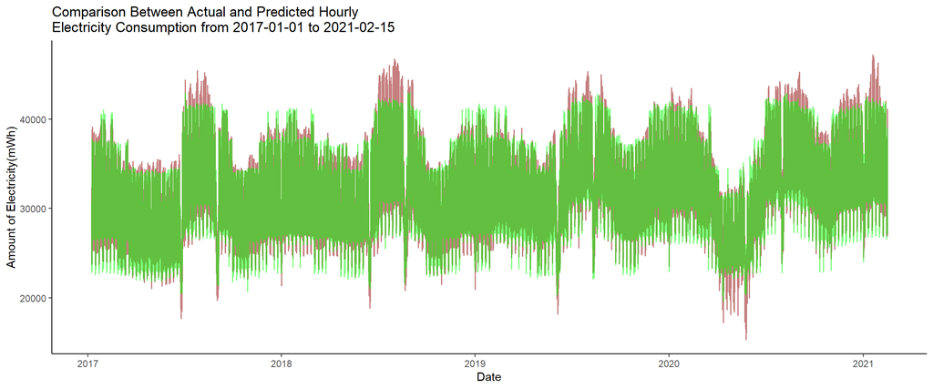

```r
a <- ggplot(rawconsumption, aes(x=rawconsumption$event_date)) +
  geom_line(aes(y=rawconsumption$consumption), size = 0.6, color="darkred", alpha = 0.5) +
  geom_line(aes(y=rawconsumption$fitted), size = 0.6, color="green", alpha = 0.5) +
  labs(title = "Comparison Between Actual and Predicted Hourly\nElectricity Consumption from 2017-01-01 to 2021-02-15",
       x = "Date",y = "Amount of Electricity(mWh)") +
  theme_classic()
a
```

The predictions generally seem to suit with the actual values. It is observed that necessary changes are made in the forecasts of special days. However, it is also observed that the forecasts deviate especially in cases where the actual value exceeds 40 thousand. There was a decrease in the forecasts during the first three months of coronavirus period, which is desired, but this decrease was not enough.

Furthermore, this comparison can be seen in detail by narrowing the period. (real prediction period) The day in which prediction is made is assumed to be 14th of February. The prediction for 15th of February can be seen more easily in the graph below.

[figure not shown]

```r
lastvalue <- tail(rawconsumption, 24)

b<- ggplot(lastvalue, aes(x=lastvalue$trend)) +
  geom_line(aes(y=lastvalue$consumption), size = 0.6, color="darkred", alpha = 0.5) +
  geom_line(aes(y=lastvalue$fitted), size = 0.6, color="green", alpha = 0.5) +
  labs(title = "Comparison Between Actual and Predicted Hourly\nElectricity Consumption For Last Two Day",
       x = "Index",y = "Amount of Electricity(mWh)") +
  theme_classic()
b
```

# Conclusion and Further Remarks

The hourly time series data generally have multiple seasonal components which make them kind of harder to interpret. Apart from that, even after some data manipulation techniques, the time series data still may not fulfill condition to be stationary. Therefore, it is not easy to make clear cut forecasts when considering the time series data. However, with today’s computational power of computers and logical reasoning, it is possible to add and subtract variables from a system and observe if the variables have any statistically significant effect on the data.

It is possible to say that the results found in the study were generally good results. MAPE/WMAPE values allow us to say this. Although the prediction model works well overall, it is obvious that it has some shortcomings. As can be seen from the graphics above, it has problems when the consumption exceeds 40 thousand and it cannot fully reflect the coronavirus effect. Coronavirus effect and restrictions should be used more effectively in order to improve the model. High consumption values, especially in the summer period, are not reflected in the estimates, and improvements can be made to solve this problem.

# References

- [EPIAS](https://seffaflik.epias.com.tr/transparency/tuketim/gerceklesen-tuketim/gercek-zamanli-tuketim.xhtml)
- [STHDA](http://www.sthda.com/english/)
- [Stackoverflow](https://stackoverflow.com/)

# Appendices

Click [here](https://bu-ie-360.github.io/fall20-mibaykal/files/Group8Report.Rmd) to reach the RMD file.